# Виды анализа данных

Разведочный и причинно-следственный анализ

Кузнецов Фёдор

11.10.2026

# 1 Введение

В этой работе рассматриваются два вида анализа данных:

- **разведочный анализ данных** (*Exploratory Data Analysis, EDA*);
- **причинно-следственный анализ** (*causal analysis*).

Цель работы — показать на примерах научных публикаций, чем отличаются эти подходы, какие исследовательские вопросы они решают и почему выбранные статьи относятся именно к соответствующим видам анализа.

## 1.1 Используемые исследования

В работе используются две научные публикации:

1. **Konopka B. M., Lwow F., Owczarz M., Łaczmański Ł. (2018).** *Exploratory data analysis of a clinical study group: Development of a procedure for exploring multidimensional data*. PLOS ONE, 13(8), e0201950. DOI: 10.1371/journal.pone.0201950
2. **Baicker K., Taubman S. L., Allen H. L. et al. (2013).** *The Oregon Experiment — Effects of Medicaid on Clinical Outcomes*. New England Journal of Medicine, 368, 1713–1722. DOI: 10.1056/NEJMsa1212321

## 1.2 Репозиторий проекта

[Репозиторий проекта на GitHub](https://github.com/Fedmog1lnkv-ISU-Homework/Data-cleaning)

# 2 Разведочный анализ данных

## 2.1 Что такое разведочный анализ

Разведочный анализ данных применяется тогда, когда исследователю необходимо сначала **понять структуру данных**, а уже затем формулировать более узкие гипотезы.

Типичные задачи EDA:

- изучение распределений признаков;
- поиск выбросов;
- обнаружение групп похожих наблюдений;
- анализ взаимосвязей между переменными;
- снижение размерности;
- визуальное представление сложных многомерных данных.

Иными словами, главный вопрос разведочного анализа можно сформулировать так:

> **Какие закономерности, группы и необычные наблюдения присутствуют в данных?**

### 2.1.1 Пример математического представления

Одним из распространённых инструментов разведочного анализа является метод главных компонент (*Principal Component Analysis, PCA*).

Проекцию исходных данных можно записать как

$$Z = XW,$$

где:

- $X$ — исходная матрица признаков;
- $W$ — матрица выбранных главных компонент;
- $Z$ — представление объектов в пространстве меньшей размерности.

Для обнаружения многомерных выбросов может использоваться расстояние Махаланобиса:

$$D_M(x) =
\sqrt{
(x-\mu)^T \Sigma^{-1}(x-\mu)
},$$

где $\mu$ — вектор средних значений, а $\Sigma$ — ковариационная матрица.

## 2.2 Пример исследования: Konopka et al. (2018)

В статье Konopka и соавторов анализировались данные **515 пожилых участников** исследования PolSenior.

Набор данных содержал большое количество биохимических, клинических и социально-демографических характеристик. Авторы стремились понять внутреннюю структуру этих многомерных данных и предложить процедуру их последовательного исследования.

В работе применялись:

1. нормализация данных;
2. обнаружение выбросов с помощью расстояния Махаланобиса;
3. иерархическая кластеризация методом Уорда;
4. метод главных компонент (PCA);
5. визуальное исследование полученных групп и зависимостей.

Авторы подчёркивают роль понимания структуры данных:

> “Thorough knowledge of the structure of analyzed data allows to form detailed scientific hypotheses and research questions.”

## 2.3 Почему это именно разведочный анализ

Это исследование относится к EDA по нескольким причинам.

Во-первых, авторы **не проверяют одну заранее заданную причинную гипотезу** вида «X вызывает Y».

Во-вторых, основной результат анализа — описание структуры данных:

- какие признаки связаны между собой;
- какие наблюдения отличаются от остальных;
- какие естественные группы можно выделить;
- какие направления вариации являются наиболее важными.

В-третьих, применяемые методы — PCA, кластеризация и поиск выбросов — используются именно для **исследования структуры**, а не для оценки причинного эффекта.

Логику работы можно представить следующим образом:

**данные → исследование структуры → поиск закономерностей → формирование новых гипотез.**

# 3 Причинно-следственный анализ

## 3.1 Что такое причинно-следственный анализ

Причинно-следственный анализ используется, когда исследователь хочет ответить на вопрос:

> **Вызывает ли изменение фактора X изменение результата Y?**

Здесь важно отличать **корреляцию** от **причинности**.

Если переменные $X$ и $Y$ статистически связаны, это ещё не означает, что $X$ является причиной $Y$. На обе переменные может влиять третий фактор.

Один из способов формально представить причинный эффект — использовать потенциальные исходы.

Средний причинный эффект (*Average Treatment Effect, ATE*) можно записать как

$$ATE = E[Y(1) - Y(0)],$$

где:

- $Y(1)$ — результат при наличии воздействия;
- $Y(0)$ — результат при отсутствии воздействия.

Проблема заключается в том, что для одного и того же человека одновременно наблюдать $Y(1)$ и $Y(0)$ невозможно. Поэтому особенно важен дизайн исследования.

## 3.2 Пример исследования: Oregon Health Insurance Experiment

В работе Baicker et al. изучались последствия расширения программы медицинского страхования Medicaid в штате Орегон.

Количество мест в программе было ограничено, поэтому возможность подать заявку на Medicaid распределялась с помощью **случайной лотереи**.

Примерно через два года исследователи получили клинические данные:

- для **6387 взрослых**, выбранных лотереей;
- для **5842 взрослых**, не выбранных лотереей.

Измерялись:

- артериальное давление;
- уровень холестерина;
- гликированный гемоглобин;
- наличие депрессивных симптомов;
- использование медицинских услуг;
- финансовые расходы, связанные с лечением.

## 3.3 Почему это причинно-следственный анализ

Ключевой элемент исследования — **случайная лотерея**.

Она позволяет сформировать группы, различия между которыми не определяются сознательным выбором участников. Благодаря этому снижается влияние факторов, которые могли бы исказить обычное сравнение людей со страховкой и без неё.

Например, при простом наблюдательном сравнении группы могли бы заранее отличаться по:

- уровню дохода;
- состоянию здоровья;
- возрасту;
- отношению к лечению;
- частоте обращений к врачам.

Случайный выбор уменьшает эту проблему.

Важно отметить, что лотерея случайно распределяла **возможность подать заявку на Medicaid**, а не само страховое покрытие. Поэтому авторы использовали случайный выбор как источник внешней вариации и как инструмент для оценки эффекта Medicaid.

Таким образом, исследовательский вопрос имеет причинную форму:

**Какие изменения происходят вследствие получения доступа к Medicaid?**

## 3.4 Основные результаты исследования

Авторы не обнаружили статистически значимого улучшения ряда физических показателей здоровья, включая:

- артериальное давление;
- уровень холестерина;
- средний уровень гликированного гемоглобина.

При этом доступ к Medicaid был связан с причинными изменениями по другим исходам:

1. увеличилась вероятность диагностики диабета;
2. увеличилось использование лекарств для лечения диабета;
3. снизилась вероятность положительного скрининга на депрессию;
4. увеличилось использование медицинских услуг;
5. снизилась финансовая нагрузка, связанная с медицинскими расходами.

Поэтому вывод исследования нельзя упрощать до фразы «Medicaid улучшает здоровье».

Более корректно сказать:

> Доступ к Medicaid вызвал заметные изменения в использовании медицинской помощи, финансовой защите и некоторых показателях здоровья, но не привёл к статистически значимому улучшению ряда измеряемых физических показателей за рассматриваемый период.

# 4 Визуальное сравнение подходов

На рисунке ниже показано главное различие между двумя типами анализа.

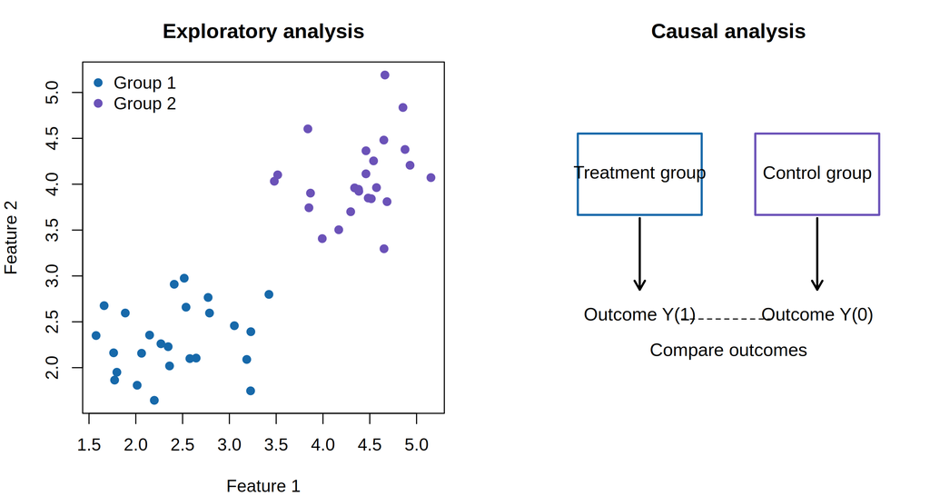

Концептуальное различие между разведочным и причинно-следственным анализом

# 5 Сравнение исследований

## 5.1 Краткая характеристика статей

Краткая характеристика выбранных исследований

| Параметр | Konopka et al. (2018) | Baicker et al. (2013) |
| --- | --- | --- |
| Публикация | PLOS ONE | New England Journal of Medicine |
| Тип анализа | Разведочный | Причинно-следственный |
| Объект исследования | 515 пожилых участников | Участники лотереи Medicaid |
| Ключевой метод | PCA, кластеризация, выбросы | Случайная лотерея и сравнение групп |
| Главная цель | Понять структуру многомерных данных | Оценить последствия доступа к Medicaid |

## 5.2 Сравнение видов анализа

Сравнение разведочного и причинно-следственного анализа

| Критерий | Разведочный анализ | Причинно-следственный анализ |
| --- | --- | --- |
| Основной вопрос | Что интересного есть в данных? | Вызывает ли X изменение Y? |
| Цель | Найти структуру и закономерности | Оценить причинный эффект |
| Типичные методы | Визуализация, PCA, кластеризация, поиск выбросов | Эксперимент, рандомизация, квазиэксперимент, инструментальные переменные |
| Нужна ли заранее заданная причинная гипотеза | Нет | Да |
| Тип результата | Группы, связи, выбросы, новые гипотезы | Оценка эффекта воздействия |

# 6 Вывод

Рассмотренные исследования демонстрируют два принципиально разных подхода к анализу данных.

**Разведочный анализ** используется тогда, когда исследователь хочет понять, как устроены данные. В работе Konopka et al. применяются PCA, кластеризация и поиск выбросов, а результатом становится описание структуры многомерного набора данных и формирование новых исследовательских вопросов.

**Причинно-следственный анализ** используется тогда, когда требуется оценить эффект конкретного воздействия. В Oregon Health Insurance Experiment случайная лотерея создаёт основу для причинного сравнения и позволяет оценивать последствия доступа к Medicaid.

Главное различие можно сформулировать кратко:

- **EDA:** «Что содержится в данных?»
- **Causal analysis:** «Что изменилось именно из-за воздействия X?»

# 7 Источники

1. Konopka, B. M., Lwow, F., Owczarz, M., & Łaczmański, Ł. (2018). *Exploratory data analysis of a clinical study group: Development of a procedure for exploring multidimensional data*. **PLOS ONE, 13**(8), e0201950. https://doi.org/10.1371/journal.pone.0201950
2. Baicker, K., Taubman, S. L., Allen, H. L., et al. (2013). *The Oregon Experiment — Effects of Medicaid on Clinical Outcomes*. **New England Journal of Medicine, 368**, 1713–1722. https://doi.org/10.1056/NEJMsa1212321